# Analyzing Data with R

UCI DataScience Initiative

September 16, 2015

# Data Exploration

## Example 1 - Data Exploration using mtcars{car}:

We load “mtcars” dataset from car library:

```r
# install.packages(repos = "http://cran.stat.ucla.edu", "car")
library(car)
str(mtcars) # or ?mtcars
```

```
## 'data.frame':    32 obs. of  11 variables:
##  $ mpg : num  21 21 22.8 21.4 18.7 18.1 14.3 24.4 22.8 19.2 ...
##  $ cyl : num  6 6 4 6 8 6 8 4 4 6 ...
##  $ disp: num  160 160 108 258 360 ...
##  $ hp  : num  110 110 93 110 175 105 245 62 95 123 ...
##  $ drat: num  3.9 3.9 3.85 3.08 3.15 2.76 3.21 3.69 3.92 3.92 ...
##  $ wt  : num  2.62 2.88 2.32 3.21 3.44 ...
##  $ qsec: num  16.5 17 18.6 19.4 17 ...
##  $ vs  : num  0 0 1 1 0 1 0 1 1 1 ...
##  $ am  : num  1 1 1 0 0 0 0 0 0 0 ...
##  $ gear: num  4 4 4 3 3 3 3 4 4 4 ...
##  $ carb: num  4 4 1 1 2 1 4 2 2 4 ...
```

We can learn more about the dataset by:

```r
# install.packages(repos = "http://cran.stat.ucla.edu", "car")
dim(mtcars)
```

```
## [1] 32 11
```

```r
colnames(mtcars)
```

```
##  [1] "mpg"  "cyl"  "disp" "hp"   "drat" "wt"   "qsec" "vs"   "am"   "gear"
## [11] "carb"
```

Let’s only focus on attributes that we are intereted in:

```r
# we can take a subset of the data:
mtcars_sub <- mtcars[,c("mpg", "cyl", "hp", "wt", "am", "gear")]

# What is "am"?? ---> ?mtcars

# changing "am" to an informative name:
names(mtcars_sub)[names(mtcars_sub) == "am"] <- "ManualTrans"
```

Let’s explore the data!!

```r
# About the data:
summary(mtcars_sub$mpg)
```

```
##    Min. 1st Qu.  Median    Mean 3rd Qu.    Max.
##   10.40   15.42   19.20   20.09   22.80   33.90
```

```r
summary(mtcars_sub)
```

```
##       mpg             cyl              hp              wt
##  Min.   :10.40   Min.   :4.000   Min.   : 52.0   Min.   :1.513
##  1st Qu.:15.43   1st Qu.:4.000   1st Qu.: 96.5   1st Qu.:2.581
##  Median :19.20   Median :6.000   Median :123.0   Median :3.325
##  Mean   :20.09   Mean   :6.188   Mean   :146.7   Mean   :3.217
##  3rd Qu.:22.80   3rd Qu.:8.000   3rd Qu.:180.0   3rd Qu.:3.610
##  Max.   :33.90   Max.   :8.000   Max.   :335.0   Max.   :5.424
##   ManualTrans          gear
##  Min.   :0.0000   Min.   :3.000
##  1st Qu.:0.0000   1st Qu.:3.000
##  Median :0.0000   Median :4.000
##  Mean   :0.4062   Mean   :3.688
##  3rd Qu.:1.0000   3rd Qu.:4.000
##  Max.   :1.0000   Max.   :5.000
```

```r
# for discrete attributes:
table(mtcars_sub$gear)
```

```
##
##  3  4  5
## 15 12  5
```

```r
table(mtcars_sub$ManualTrans)
```

```
##
##  0  1
## 19 13
```

```r
NumCyl <- table(mtcars_sub$cyl)
NumCyl
```

```
##
##  4  6  8
## 11  7 14
```

```r
# two-way freq tables:
table(mtcars_sub$ManualTrans, mtcars_sub$gear)
```

```
##
##      3  4  5
##   0 15  4  0
##   1  0  8  5
```

```r
freqTable <- table(mtcars_sub$ManualTrans, mtcars_sub$gear)
rownames(freqTable) <- c("Automatic", "Manual")
colnames(freqTable) <- paste(3:5, "gears", sep = "-")
freqTable
```

```
##
##             3-gears 4-gears 5-gears
##   Automatic      15       4       0
##   Manual          0       8       5
```

```r
kable(freqTable, caption = "Freq Table of Transmission vs. Number of Forward gears")
```

Freq Table of Transmission vs. Number of Forward gears

|  | 3-gears | 4-gears | 5-gears |
| --- | --- | --- | --- |
| Automatic | 15 | 4 | 0 |
| Manual | 0 | 8 | 5 |

# Visual data exploration:

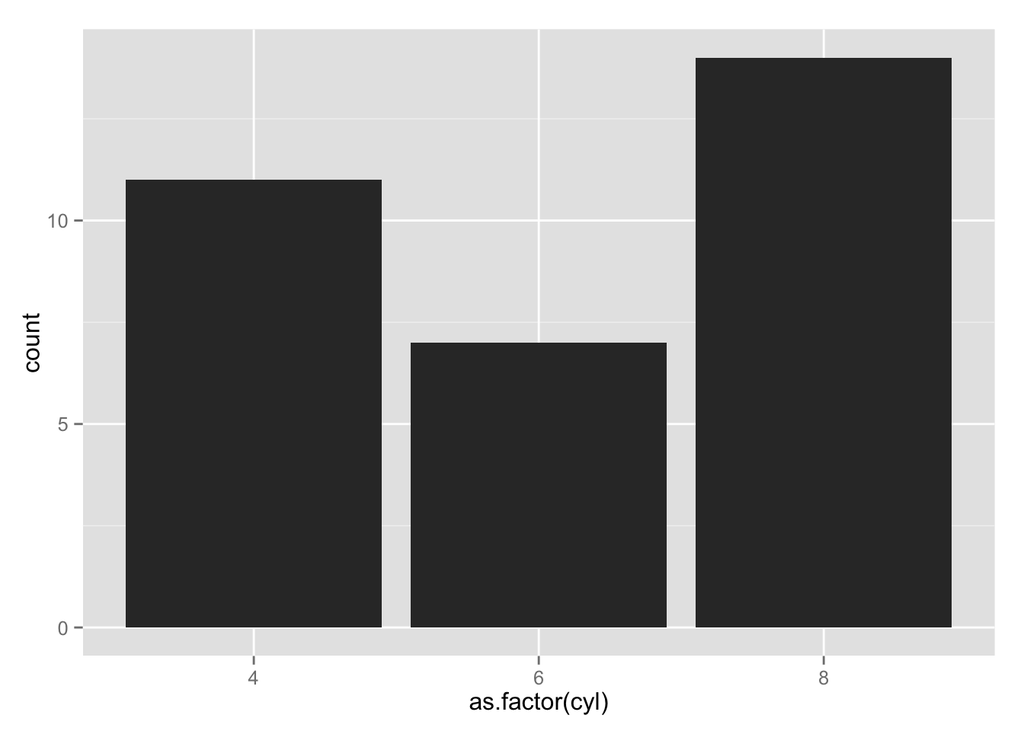

```r
library(ggplot2)
ggplot(mtcars_sub, aes(as.factor(cyl))) + geom_histogram(binwidth = 1)
```

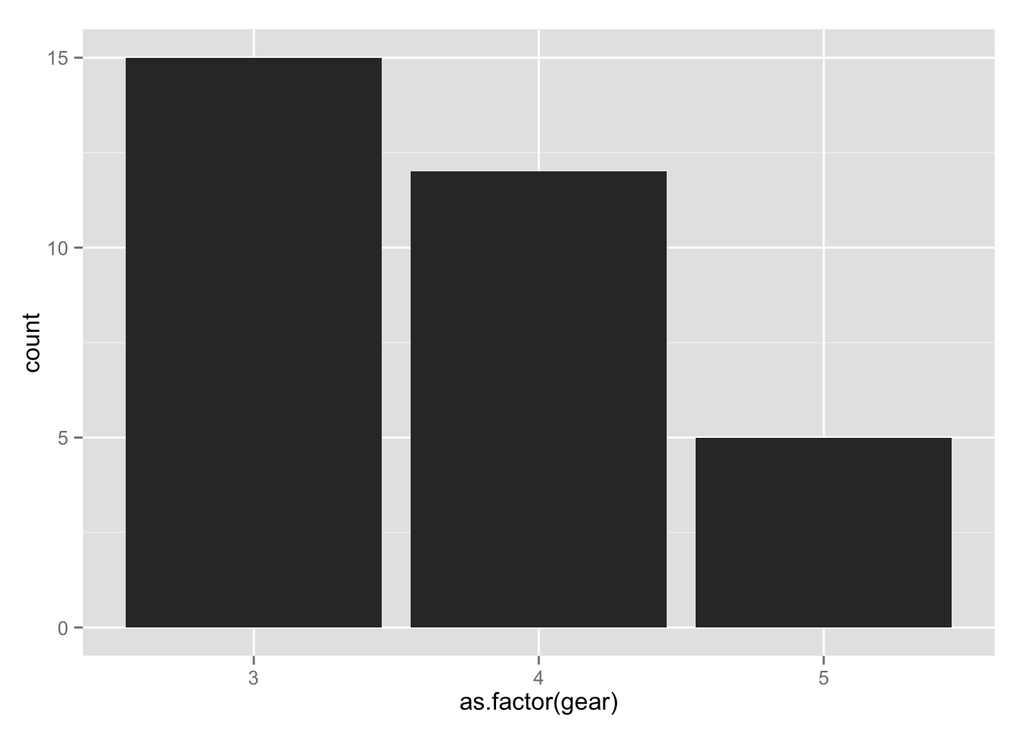

```r
ggplot(mtcars_sub, aes(as.factor(gear))) + geom_histogram()
```

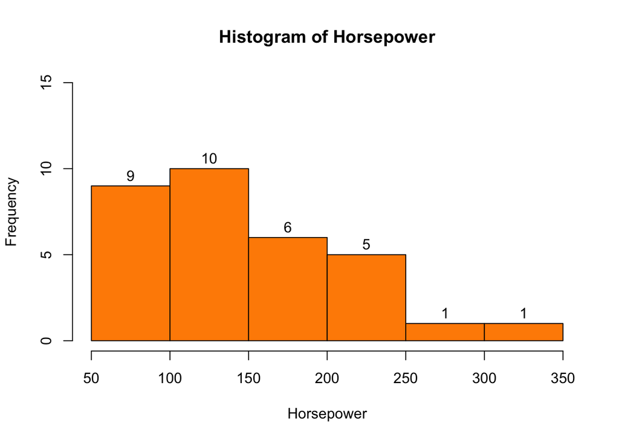

```r
# Using R's base plotting package
hist(mtcars_sub$hp, ylim = c(0, 15), col = "darkorange", labels = T, xlab = "Horsepower", main = "Histogram of Horsepower")
```

mpg for automatic vs. manual:

```r
mpgForAutoCars <- mtcars_sub$mpg[mtcars_sub$ManualTrans == 0]
mpgForManuCars <- mtcars_sub$mpg[mtcars_sub$ManualTrans == 1]

c(AutoCars = mean(mpgForAutoCars), ManCars = mean(mpgForManuCars))
```

```
## AutoCars  ManCars
## 17.14737 24.39231
```

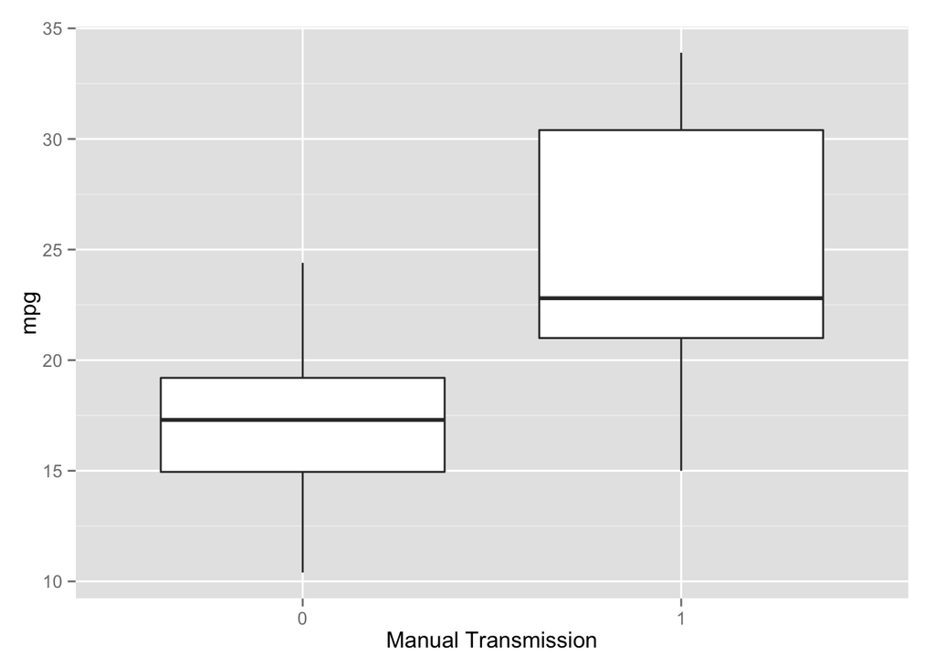

```r
# Does that make sense? Manual cars have better MPG than automatic cars!

ggplot(mtcars_sub, aes(as.factor(ManualTrans), mpg)) + geom_boxplot() + xlab("Manual Transmission")
```

what are other related factors to mpg? maybe, number of Cylinders?!

```r
tapply(mtcars_sub$mpg, mtcars_sub$cyl, mean)
```

```
##        4        6        8
## 26.66364 19.74286 15.10000
```

```r
# Maybe it's better to compare mpg between Auto and Manu for cars with the same # cylinders
mtcars_man <- mtcars_sub[mtcars_sub$ManualTrans == 1,]
mtcars_aut <- mtcars_sub[mtcars_sub$ManualTrans == 0,]
MPG_Man_vs_Aut <- rbind("Manual" = tapply(mtcars_man$mpg, mtcars_man$cyl, mean),
                        "Automatic" =  tapply(mtcars_aut$mpg, mtcars_aut$cyl, mean))
kable(MPG_Man_vs_Aut, caption = "MPG of Manual Cars v. Automatic per Num. Cylinders", digits = 1)
```

MPG of Manual Cars v. Automatic per Num. Cylinders

|  | 4 | 6 | 8 |
| --- | --- | --- | --- |
| Manual | 28.1 | 20.6 | 15.4 |
| Automatic | 22.9 | 19.1 | 15.1 |

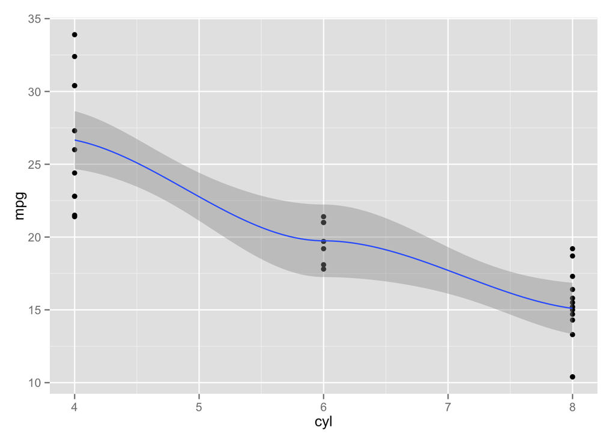

```r
# mpg vs. horsepower (scatterplot)
# scatterplot:
ggplot(mtcars_sub, aes(cyl, mpg)) + geom_point() + stat_smooth()
```

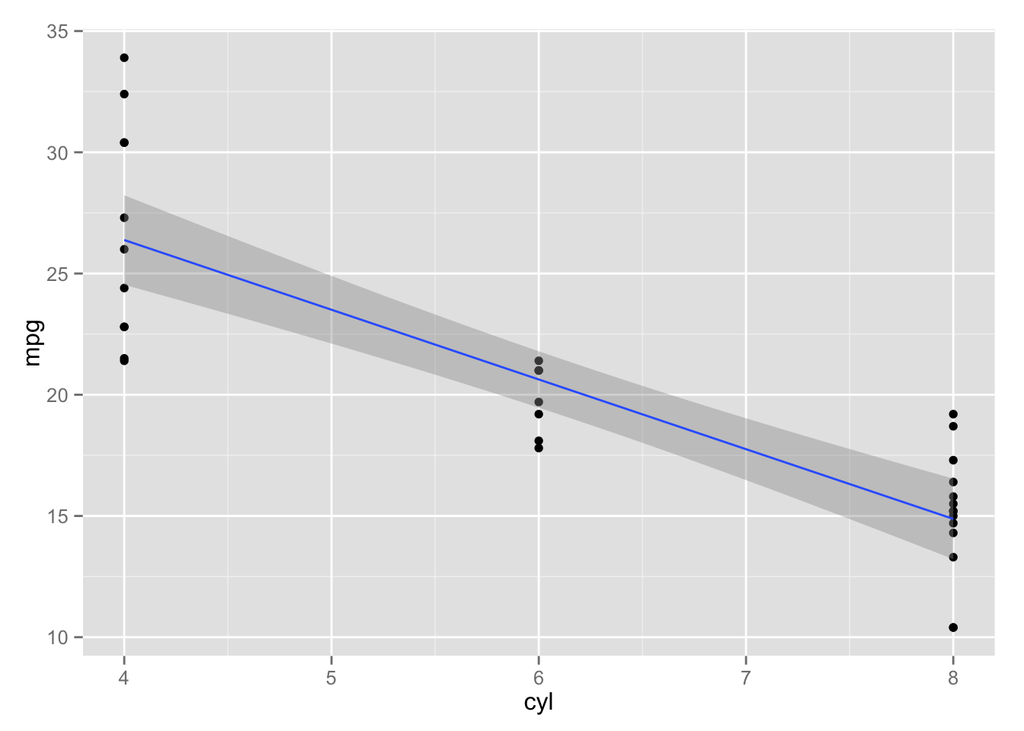

```r
ggplot(mtcars, aes(cyl, mpg)) + geom_point() + stat_smooth(method="lm")
```

## Example 2 - D3-Style Data Visualization in R:

```r
library(rCharts)
library(rMaps)
library(choroplethr)
library(XML)
library(selectr)
```

### Interactive Bar-Charts:

```r
# HairEyeColor table:
# str(HairEyeColor)
# HairEyeColor
hair_eye_male <- subset(as.data.frame(HairEyeColor), Sex == "Male")
# hair_eye_male
n1 <- nPlot(Freq ~ Hair, group = "Eye", data = hair_eye_male, type = "multiBarChart")
n1$chart(color = c('brown', 'blue', '#594c26', 'green'))
n1$print('iframesrc', include_assets=TRUE)
```

### Looking at multiple variables at once!

```r
myHPlot <- hPlot(Pulse ~ Height, data = MASS::survey, size = "Age", group = "Exer", type = "bubble", title = "Zoom demo",
      subtitle = "bubble chart")

# to print:
myHPlot$print('iframesrc', include_assets=TRUE)
```

# Data Analysis:

## Example1 - Logistic Regression:

> Reference: http://www.ats.ucla.edu

In the logit model the log odds of the outcome is modeled as a linear combination of the predictor variables.

```r
library(aod)
library(ggplot2)

mydata <- read.csv("http://www.ats.ucla.edu/stat/data/binary.csv")
## view the first few rows of the data
head(mydata)
```

```
##   admit gre  gpa rank
## 1     0 380 3.61    3
## 2     1 660 3.67    3
## 3     1 800 4.00    1
## 4     1 640 3.19    4
## 5     0 520 2.93    4
## 6     1 760 3.00    2
```

```r
summary(mydata)
```

```
##      admit             gre             gpa             rank
##  Min.   :0.0000   Min.   :220.0   Min.   :2.260   Min.   :1.000
##  1st Qu.:0.0000   1st Qu.:520.0   1st Qu.:3.130   1st Qu.:2.000
##  Median :0.0000   Median :580.0   Median :3.395   Median :2.000
##  Mean   :0.3175   Mean   :587.7   Mean   :3.390   Mean   :2.485
##  3rd Qu.:1.0000   3rd Qu.:660.0   3rd Qu.:3.670   3rd Qu.:3.000
##  Max.   :1.0000   Max.   :800.0   Max.   :4.000   Max.   :4.000
```

```r
sapply(mydata, sd)
```

```
##       admit         gre         gpa        rank
##   0.4660867 115.5165364   0.3805668   0.9444602
```

```r
## two-way contingency table of categorical outcome and predictors we want
## to make sure there are not 0 cells
xtabs(~admit + rank, data = mydata)
```

```
##      rank
## admit  1  2  3  4
##     0 28 97 93 55
##     1 33 54 28 12
```

```r
mydata$rank <- factor(mydata$rank)

mylogit <- glm(admit ~ gre + gpa + rank, data = mydata, family = "binomial")
summary(mylogit)
```

```
##
## Call:
## glm(formula = admit ~ gre + gpa + rank, family = "binomial",
##     data = mydata)
##
## Deviance Residuals:
##     Min       1Q   Median       3Q      Max
## -1.6268  -0.8662  -0.6388   1.1490   2.0790
##
## Coefficients:
##              Estimate Std. Error z value Pr(>|z|)
## (Intercept) -3.989979   1.139951  -3.500 0.000465 ***
## gre          0.002264   0.001094   2.070 0.038465 *
## gpa          0.804038   0.331819   2.423 0.015388 *
## rank2       -0.675443   0.316490  -2.134 0.032829 *
## rank3       -1.340204   0.345306  -3.881 0.000104 ***
## rank4       -1.551464   0.417832  -3.713 0.000205 ***
## ---
## Signif. codes:  0 '***' 0.001 '**' 0.01 '*' 0.05 '.' 0.1 ' ' 1
##
## (Dispersion parameter for binomial family taken to be 1)
##
##     Null deviance: 499.98  on 399  degrees of freedom
## Residual deviance: 458.52  on 394  degrees of freedom
## AIC: 470.52
##
## Number of Fisher Scoring iterations: 4
```

```r
exp(coef(mylogit))
```

```
## (Intercept)         gre         gpa       rank2       rank3       rank4
##   0.0185001   1.0022670   2.2345448   0.5089310   0.2617923   0.2119375
```

- For every one unit change in gre, the log odds of admission (versus non-admission) increases by 0.002.
- For a one unit increase in gpa, the log odds of being admitted to graduate school increases by 0.804.
- The indicator variables for rank have a slightly different interpretation. For example, having attended an
- undergraduate institution with rank of 2, versus an institution with a rank of 1, changes the log odds of admission by -0.675.

We can use the confint function to obtain confidence intervals for the coefficient estimates.

```r
confint(mylogit)
```

```
##                     2.5 %       97.5 %
## (Intercept) -6.2716202334 -1.792547080
## gre          0.0001375921  0.004435874
## gpa          0.1602959439  1.464142727
## rank2       -1.3008888002 -0.056745722
## rank3       -2.0276713127 -0.670372346
## rank4       -2.4000265384 -0.753542605
```

```r
exp(cbind(OR = coef(mylogit), confint(mylogit)))
```

```
##                    OR       2.5 %    97.5 %
## (Intercept) 0.0185001 0.001889165 0.1665354
## gre         1.0022670 1.000137602 1.0044457
## gpa         2.2345448 1.173858216 4.3238349
## rank2       0.5089310 0.272289674 0.9448343
## rank3       0.2617923 0.131641717 0.5115181
## rank4       0.2119375 0.090715546 0.4706961
```

```r
# We can test for an overall effect of rank using the wald.test function of the aod library.
wald.test(b = coef(mylogit), Sigma = vcov(mylogit), Terms = 4:6)
```

```
## Wald test:
## ----------
##
## Chi-squared test:
## X2 = 20.9, df = 3, P(> X2) = 0.00011
```

Using our modelm we can do prediction. In order to create predicted probabilities we first need to create a new data frame with the values we want the independent variables to take on to create our predictions.

```r
newdata1 <- with(mydata, data.frame(gre = mean(gre), gpa = mean(gpa), rank = factor(1:4)))
newdata1$rankP <- predict(mylogit, newdata = newdata1, type = "response")
newdata1
```

```
##     gre    gpa rank     rankP
## 1 587.7 3.3899    1 0.5166016
## 2 587.7 3.3899    2 0.3522846
## 3 587.7 3.3899    3 0.2186120
## 4 587.7 3.3899    4 0.1846684
```

In the above output we see that the predicted probability of being accepted into a graduate program is 0.52 for students from the highest prestige undergraduate institutions (rank=1), and 0.18 for students from the lowest ranked institutions (rank=4), holding gre and gpa at their means. To get prediction at different levels of predictors, we can do:

```r
newdata2 <- with(mydata, data.frame(gre = rep(seq(from = 200, to = 800, length.out = 100),4), gpa = mean(gpa),
                                    rank = factor(rep(1:4, each = 100))))

newdata3 <- cbind(newdata2, predict(mylogit, newdata = newdata2, type = "link", se = TRUE))

newdata3 <- within(newdata3, {
  PredictedProb <- plogis(fit)
  LL <- plogis(fit - (1.96 * se.fit))
  UL <- plogis(fit + (1.96 * se.fit))
})

## view first few rows of final dataset
head(newdata3)
```

```
##        gre    gpa rank        fit    se.fit residual.scale        UL
## 1 200.0000 3.3899    1 -0.8114870 0.5147714              1 0.5492064
## 2 206.0606 3.3899    1 -0.7977632 0.5090986              1 0.5498513
## 3 212.1212 3.3899    1 -0.7840394 0.5034491              1 0.5505074
## 4 218.1818 3.3899    1 -0.7703156 0.4978239              1 0.5511750
## 5 224.2424 3.3899    1 -0.7565919 0.4922237              1 0.5518545
## 6 230.3030 3.3899    1 -0.7428681 0.4866494              1 0.5525464
##          LL PredictedProb
## 1 0.1393812     0.3075737
## 2 0.1423880     0.3105042
## 3 0.1454429     0.3134499
## 4 0.1485460     0.3164108
## 5 0.1516973     0.3193867
## 6 0.1548966     0.3223773
```

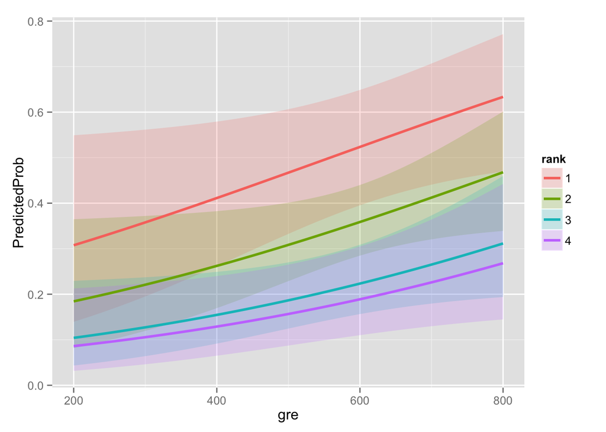

```r
# Below we make a plot with the predicted probabilities, and 95% confidence intervals.
ggplot(newdata3, aes(x = gre, y = PredictedProb)) + geom_ribbon(aes(ymin = LL, ymax = UL, fill = rank), alpha = 0.2) + geom_line(aes(colour = rank),size = 1)
```

## Example2 - Count Data:

- Here, we consider the number of awards earned by students at one high school.
- Predictors of the number of awards earned include:
- the type of program in which the student was enrolled (e.g., vocational, general or academic) and the score on
- their final exam in math.

```r
require(ggplot2)
require(sandwich)
require(msm)
p <- read.csv("http://www.ats.ucla.edu/stat/data/poisson_sim.csv")
p <- within(p, {
  prog <- factor(prog, levels=1:3, labels=c("General", "Academic", "Vocational"))
  id <- factor(id)
})
head(p)
```

```
##    id num_awards       prog math
## 1  45          0 Vocational   41
## 2 108          0    General   41
## 3  15          0 Vocational   44
## 4  67          0 Vocational   42
## 5 153          0 Vocational   40
## 6  51          0    General   42
```

```r
summary(p)
```

```
##        id        num_awards           prog          math
##  1      :  1   Min.   :0.00   General   : 45   Min.   :33.00
##  2      :  1   1st Qu.:0.00   Academic  :105   1st Qu.:45.00
##  3      :  1   Median :0.00   Vocational: 50   Median :52.00
##  4      :  1   Mean   :0.63                    Mean   :52.65
##  5      :  1   3rd Qu.:1.00                    3rd Qu.:59.00
##  6      :  1   Max.   :6.00                    Max.   :75.00
##  (Other):194
```

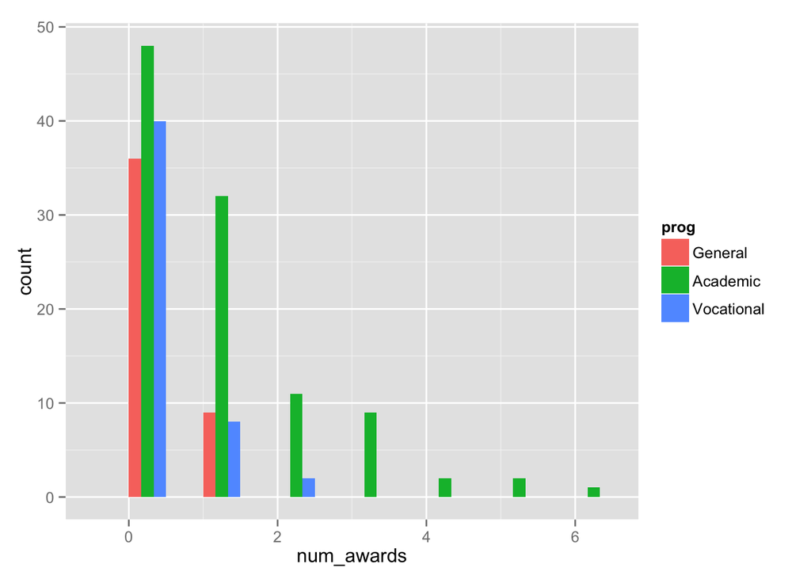

```r
ggplot(p, aes(num_awards, fill = prog)) + geom_histogram(binwidth=.5, position="dodge")
```

```r
summary(m1 <- glm(num_awards ~ prog + math, family="poisson", data=p))
```

```
##
## Call:
## glm(formula = num_awards ~ prog + math, family = "poisson", data = p)
##
## Deviance Residuals:
##     Min       1Q   Median       3Q      Max
## -2.2043  -0.8436  -0.5106   0.2558   2.6796
##
## Coefficients:
##                Estimate Std. Error z value Pr(>|z|)
## (Intercept)    -5.24712    0.65845  -7.969 1.60e-15 ***
## progAcademic    1.08386    0.35825   3.025  0.00248 **
## progVocational  0.36981    0.44107   0.838  0.40179
## math            0.07015    0.01060   6.619 3.63e-11 ***
## ---
## Signif. codes:  0 '***' 0.001 '**' 0.01 '*' 0.05 '.' 0.1 ' ' 1
##
## (Dispersion parameter for poisson family taken to be 1)
##
##     Null deviance: 287.67  on 199  degrees of freedom
## Residual deviance: 189.45  on 196  degrees of freedom
## AIC: 373.5
##
## Number of Fisher Scoring iterations: 6
```

```r
# Cameron and Trivedi (2009) recommended using robust standard errors for the parameter estimates to control for
# mild violation of the distribution assumption that the variance equals the mean.

# We use R package sandwich below to obtain the robust standard errors and calculated the p-values accordingly:
cov.m1 <- vcovHC(m1, type="HC0")
std.err <- sqrt(diag(cov.m1))
r.est <- cbind(Estimate= coef(m1), "Robust SE" = std.err,
               "Pr(>|z|)" = 2 * pnorm(abs(coef(m1)/std.err), lower.tail=FALSE),
               LL = coef(m1) - 1.96 * std.err,
               UL = coef(m1) + 1.96 * std.err)

r.est
```

```
##                  Estimate  Robust SE     Pr(>|z|)          LL          UL
## (Intercept)    -5.2471244 0.64599839 4.566630e-16 -6.51328124 -3.98096756
## progAcademic    1.0838591 0.32104816 7.354745e-04  0.45460476  1.71311353
## progVocational  0.3698092 0.40041731 3.557157e-01 -0.41500870  1.15462716
## math            0.0701524 0.01043516 1.783975e-11  0.04969947  0.09060532
```

- Sometimes, we might want to look at the expected marginal means:
- what are the expected counts for each program type holding math score at its overall mean?
- How to answer this question? predict()

```r
s1 <- data.frame(math = mean(p$math), prog = factor(1:3, levels = 1:3, labels = levels(p$prog)))
s1
```

```
##     math       prog
## 1 52.645    General
## 2 52.645   Academic
## 3 52.645 Vocational
```

```r
predict(m1, s1, type="response", se.fit=F)
```

```
##         1         2         3
## 0.2114109 0.6249446 0.3060086
```

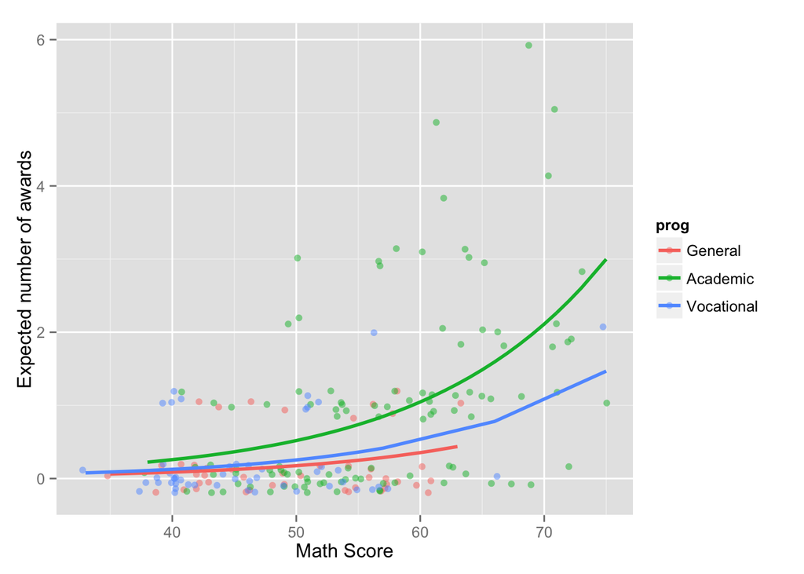

```r
## calculate and store predicted values
p$phat <- predict(m1, type="response")

## order by program and then by math
p <- p[with(p, order(prog, math)), ]

## create the plot
ggplot(p, aes(x = math, y = phat, colour = prog)) +
  geom_point(aes(y = num_awards), alpha=.5, position=position_jitter(h=.2)) +
  geom_line(size = 1) +
  labs(x = "Math Score", y = "Expected number of awards")
```